# Main Project: Classification Techniques for Predictive Modeling

## Multivariate Analysis: Cancellation Rate by Lead Time, Average Price, and Booking Status

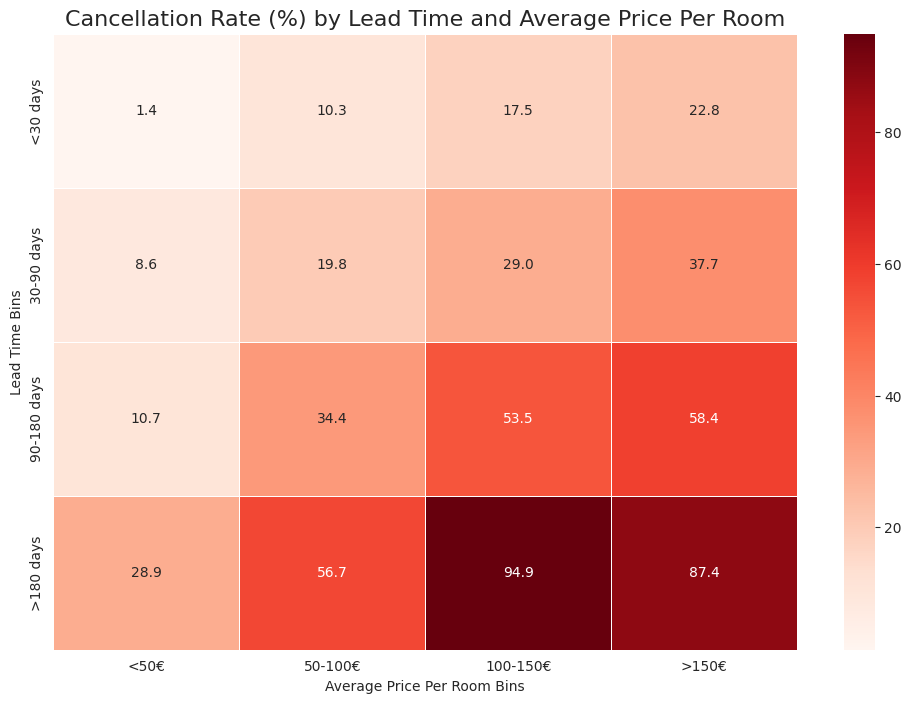

```
Cancellation rates by lead time and average price generated successfully.

Pivot Table (Cancellation Rates %):
```

| price_binned lead_time_binned | <50€ | 50-100€ | 100-150€ | >150€ |
| --- | --- | --- | --- | --- |
| <30 days | 1.440000 | 10.278179 | 17.517586 | 22.790404 |
| 30-90 days | 8.609272 | 19.809524 | 29.010989 | 37.695312 |
| 90-180 days | 10.666667 | 34.445349 | 53.514286 | 58.385093 |
| >180 days | 28.888889 | 56.678201 | 94.881890 | 87.421384 |

```python
df_multivariate = df.copy()

# Convert booking_status to numerical (1 for Canceled, 0 for Not_Canceled)
df_multivariate['booking_status_numeric'] = df_multivariate['booking_status'].apply(lambda x: 1 if x == 'Canceled' else 0)

# Create bins for lead_time
lead_time_bins = [0, 30, 90, 180, df_multivariate['lead_time'].max()]
lead_time_labels = ['<30 days', '30-90 days', '90-180 days', '>180 days']
df_multivariate['lead_time_binned'] = pd.cut(df_multivariate['lead_time'], bins=lead_time_bins, labels=lead_time_labels, right=False)

# Create bins for avg_price_per_room
price_bins = [0, 50, 100, 150, df_multivariate['avg_price_per_room'].max()]
price_labels = ['<50€', '50-100€', '100-150€', '>150€']
df_multivariate['price_binned'] = pd.cut(df_multivariate['avg_price_per_room'], bins=price_bins, labels=price_labels, right=False)

# Create the pivot table for cancellation rate
cancellation_pivot = df_multivariate.pivot_table(
    index='lead_time_binned',
    columns='price_binned',
    values='booking_status_numeric',
    aggfunc='mean'
)

plt.figure(figsize=(12, 8))
sns.heatmap(cancellation_pivot * 100, annot=True, cmap='Reds', fmt=".1f", linewidths=.5)
plt.title('Cancellation Rate (%) by Lead Time and Average Price Per Room', fontsize=16)
plt.xlabel('Average Price Per Room Bins')
plt.ylabel('Lead Time Bins')
plt.show()

print("Cancellation rates by lead time and average price generated successfully.")
print("\nPivot Table (Cancellation Rates %):")
display(cancellation_pivot * 100)
```

## Multivariate Analysis: Room Type, Market Segment, and Booking Status

### Subtask:

Analyze the cancellation rates across different room_type_reserved within various market_segment_type categories.

**Reasoning**: I will prepare the data by converting 'booking_status' to numerical values and then create a pivot table to calculate cancellation rates across room types and market segments. Finally, I'll visualize this pivot table using a heatmap.

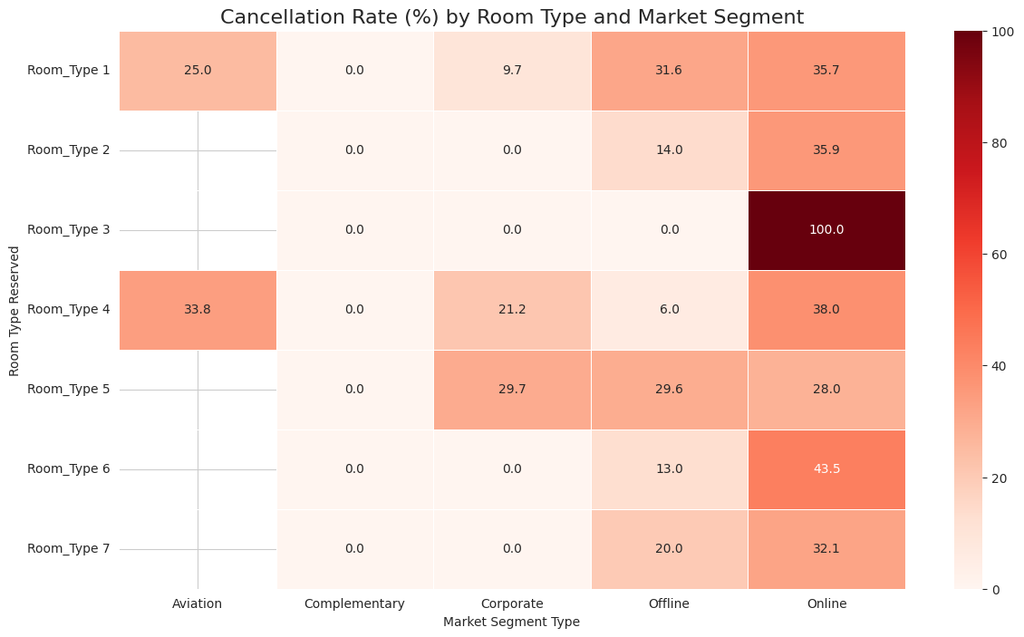

```
Cancellation rates by room type and market segment generated successfully.

Pivot Table (Cancellation Rates %):
```

| market_segment_type room_type_reserved | Aviation | Complementary | Corporate | Offline | Online |
| --- | --- | --- | --- | --- | --- |
| Room_Type 1 | 25.000000 | 0.0 | 9.656301 | 31.599467 | 35.707689 |
| Room_Type 2 | NaN | 0.0 | 0.000000 | 14.035088 | 35.889070 |
| Room_Type 3 | NaN | 0.0 | 0.000000 | 0.000000 | 100.000000 |
| Room_Type 4 | 33.846154 | 0.0 | 21.212121 | 6.035889 | 38.045142 |
| Room_Type 5 | NaN | 0.0 | 29.729730 | 29.629630 | 27.956989 |
| Room_Type 6 | NaN | 0.0 | 0.000000 | 13.043478 | 43.520518 |
| Room_Type 7 | NaN | 0.0 | 0.000000 | 20.000000 | 32.110092 |

```python
df_multivariate = df.copy()

# Convert booking_status to numerical (1 for Canceled, 0 for Not_Canceled)
df_multivariate['booking_status_numeric'] = df_multivariate['booking_status'].apply(lambda x: 1 if x == 'Canceled' else 0)

# Create the pivot table for cancellation rate by room type and market segment
cancellation_room_segment_pivot = df_multivariate.pivot_table(
    index='room_type_reserved',
    columns='market_segment_type',
    values='booking_status_numeric',
    aggfunc='mean'
)

plt.figure(figsize=(14, 8))
sns.heatmap(cancellation_room_segment_pivot * 100, annot=True, cmap='Reds', fmt=".1f", linewidths=.5)
plt.title('Cancellation Rate (%) by Room Type and Market Segment', fontsize=16)
plt.xlabel('Market Segment Type')
plt.ylabel('Room Type Reserved')
plt.show()

print("Cancellation rates by room type and market segment generated successfully.")
print("\nPivot Table (Cancellation Rates %):")
display(cancellation_room_segment_pivot * 100)
```

## Multivariate Analysis: Arrival Month, Market Segment, and Booking Status

### Subtask:

Investigate how cancellation rates vary by `arrival_month` within different `market_segment_type` categories to understand seasonal risks per channel.

**Reasoning**: To analyze cancellation rates by arrival month and market segment, I will convert 'booking_status' to numerical form, create a pivot table with `arrival_month` as index and `market_segment_type` as columns, and then visualize the results with a heatmap.

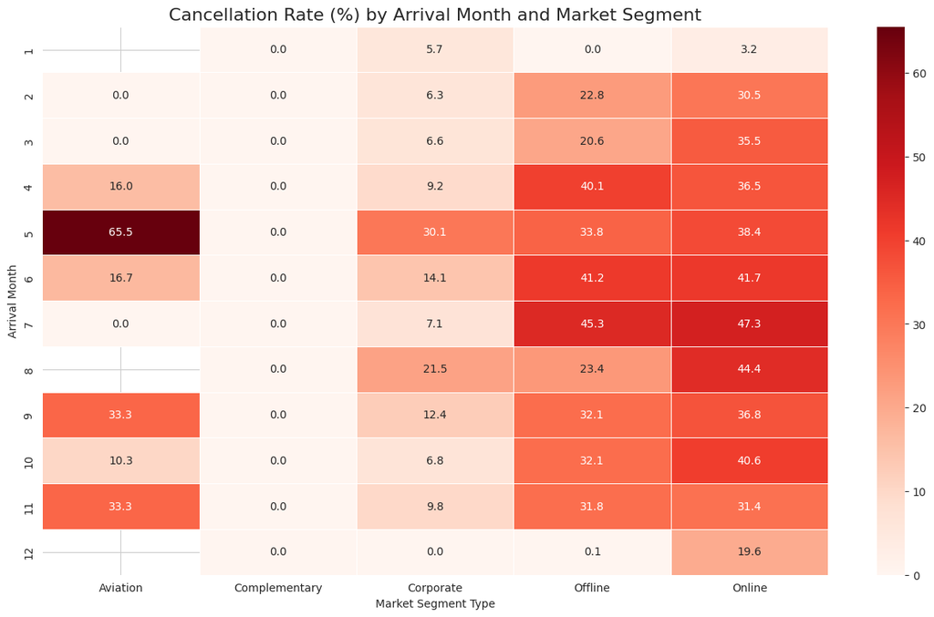

```
Cancellation rates by arrival month and market segment generated successfully.

Pivot Table (Cancellation Rates %):
```

| market_segment_type arrival_month | Aviation | Complementary | Corporate | Offline | Online |
| --- | --- | --- | --- | --- | --- |
| 1 | NaN | 0.0 | 5.660377 | 0.000000 | 3.191489 |
| 2 | 0.000000 | 0.0 | 6.310680 | 22.831050 | 30.451489 |
| 3 | 0.000000 | 0.0 | 6.586826 | 20.631970 | 35.525507 |
| 4 | 16.000000 | 0.0 | 9.230769 | 40.090772 | 36.492651 |
| 5 | 65.517241 | 0.0 | 30.136986 | 33.794163 | 38.365155 |
| 6 | 16.666667 | 0.0 | 14.141414 | 41.210795 | 41.676436 |
| 7 | 0.000000 | 0.0 | 7.079646 | 45.297806 | 47.324337 |
| 8 | NaN | 0.0 | 21.487603 | 23.378378 | 44.387052 |
| 9 | 33.333333 | 0.0 | 12.403101 | 32.097990 | 36.752137 |
| 10 | 10.344828 | 0.0 | 6.787330 | 32.059961 | 40.589032 |
| 11 | 33.333333 | 0.0 | 9.787234 | 31.835206 | 31.408898 |
| 12 | NaN | 0.0 | 0.000000 | 0.139665 | 19.647232 |

```python
df_multivariate = df.copy()

# Convert booking_status to numerical (1 for Canceled, 0 for Not_Canceled)
df_multivariate['booking_status_numeric'] = df_multivariate['booking_status'].apply(lambda x: 1 if x == 'Canceled' else 0)

# Create the pivot table for cancellation rate by arrival month and market segment
cancellation_month_segment_pivot = df_multivariate.pivot_table(
    index='arrival_month',
    columns='market_segment_type',
    values='booking_status_numeric',
    aggfunc='mean'
)

plt.figure(figsize=(16, 9))
sns.heatmap(cancellation_month_segment_pivot * 100, annot=True, cmap='Reds', fmt=".1f", linewidths=.5)
plt.title('Cancellation Rate (%) by Arrival Month and Market Segment', fontsize=16)
plt.xlabel('Market Segment Type')
plt.ylabel('Arrival Month')
plt.show()

print("Cancellation rates by arrival month and market segment generated successfully.")
print("\nPivot Table (Cancellation Rates %):")
display(cancellation_month_segment_pivot * 100)
```

**Reasoning**: I need to prepare the data by creating a pivot table to calculate the mean average price per room across room types and market segments. Finally, I'll visualize this pivot table using a heatmap.

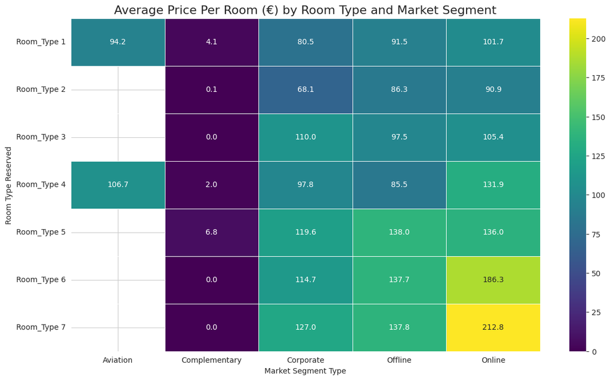

```
Average price per room by room type and market segment generated successfully.

Pivot Table (Average Price Per Room €):
```

| market_segment_type room_type_reserved | Aviation | Complementary | Corporate | Offline | Online |
| --- | --- | --- | --- | --- | --- |
| Room_Type 1 | 94.166667 | 4.064089 | 80.458532 | 91.532636 | 101.698294 |
| Room_Type 2 | NaN | 0.080000 | 68.125000 | 86.342982 | 90.916476 |
| Room_Type 3 | NaN | 0.000000 | 110.000000 | 97.500000 | 105.375000 |
| Room_Type 4 | 106.738462 | 2.038462 | 97.765354 | 85.462463 | 131.934587 |
| Room_Type 5 | NaN | 6.823529 | 119.572973 | 138.002099 | 135.987527 |
| Room_Type 6 | NaN | 0.000000 | 114.690000 | 137.731739 | 186.291253 |
| Room_Type 7 | NaN | 0.025641 | 127.000000 | 137.840000 | 212.808532 |

```python
df_multivariate = df.copy()

# Create the pivot table for average price per room by room type and market segment
avg_price_room_segment_pivot = df_multivariate.pivot_table(
    index='room_type_reserved',
    columns='market_segment_type',
    values='avg_price_per_room',
    aggfunc='mean'
)

plt.figure(figsize=(14, 8))
sns.heatmap(avg_price_room_segment_pivot, annot=True, cmap='viridis', fmt=".1f", linewidths=.5)
plt.title('Average Price Per Room (€) by Room Type and Market Segment', fontsize=16)
plt.xlabel('Market Segment Type')
plt.ylabel('Room Type Reserved')
plt.show()

print("Average price per room by room type and market segment generated successfully.")
print("\nPivot Table (Average Price Per Room €):")
display(avg_price_room_segment_pivot)
```

## Feature Interaction Discussion

The comprehensive exploratory data analysis has revealed several crucial feature interactions that significantly influence booking cancellation behavior at INN Hotels. These interactions provide a nuanced understanding beyond individual feature impacts, highlighting specific segments of customers and bookings that warrant targeted interventions.

### Overarching Business Strategies and Recommendations:

Based on these feature interactions, INN Hotels should adopt a multi-pronged, data-driven strategy:

- **Dynamic Risk-Based Pricing & Cancellation Policies:** Implement differentiated cancellation policies and deposit requirements based on the combined risk profile of **lead time, average price, and market segment**. For example, long lead-time, high-priced, online bookings should face stricter non-refundable clauses or higher upfront deposits.
- **Enhance Customer Engagement:** Actively encourage and incentivize guests to make **special requests**. This can be done through personalized pre-arrival communications, offering small perks for engaging, or designing booking flows that prompt guests for preferences. This 'micro-engagement' is a cost-effective way to boost commitment.
- **Strategic Channel Optimization:** Diversify away from over-reliance on volatile **Online segments**, especially during peak seasons. Invest in strengthening **Corporate partnerships** and identifying strategies to convert new, low-engagement online bookers into more committed segments.
- **Leverage Loyalty:** Develop a robust **loyalty program** to convert new guests into repeated guests. Prioritize and reward loyal customers with exclusive offers, upgrades, and flexible terms, as they represent almost zero cancellation risk and high lifetime value.
- **Data Quality Vigilance:** Regularly audit for data anomalies, such as bookings with zero adults, and treat any subgroup finding based on a very small sample size (e.g., single-digit booking counts) with caution before acting on it operationally.

### Key Insight:

The most profound insight from this comprehensive EDA is that **cancellation risk is not a monolithic problem but a highly dynamic and interactive phenomenon driven by a confluence of booking characteristics, customer behavior, and sales channels.** Effective mitigation requires moving beyond uniform policies to implement **granular, data-informed strategies** that account for the unique risk profiles emerging from these feature interactions. By proactively managing these interactions, INN Hotels can significantly reduce revenue leakage, optimize operational efficiency, and build stronger customer relationships.

Generate a markdown cell to introduce Section 5.7: Statistical Testing. Explain the importance of statistical validation post-EDA, covering random variation, statistical significance, business confidence, and model reliability in a professional, senior data scientist tone.

# Introduction to Statistical Testing

## Statistical Testing

### The Imperative of Statistical Validation Post-EDA

Having completed a thorough Exploratory Data Analysis (EDA), we have uncovered numerous patterns, relationships, and potential drivers within the INN Hotels booking data. While EDA provides invaluable qualitative insights and forms hypotheses, these observations are inherently descriptive and visual. To transition from anecdotal evidence to actionable business intelligence, we must subject these findings to rigorous statistical validation.

### Distinguishing Signal from Noise: Random Variation

One of the primary objectives of statistical testing is to differentiate genuine patterns from mere random variation. In any dataset, chance fluctuations can create seemingly compelling trends. Statistical tests provide a quantitative framework to assess the probability that an observed effect, such as a difference in cancellation rates between two groups, is truly systemic rather than a product of random chance. This step is critical to avoid making costly business decisions based on spurious correlations.

### Statistical Significance and its Implications

By employing hypothesis testing, we determine the statistical significance of our findings. A statistically significant result indicates that the observed pattern is unlikely to have occurred by random chance, typically quantified by a p-value below a predefined threshold (e.g., 0.05). This provides a robust, evidence-based foundation for our conclusions, allowing us to confidently assert whether a factor, such as lead time or market segment, has a measurable impact on booking status.

### Translating to Business Confidence

Statistical significance directly underpins business confidence. When we can demonstrate with a high degree of statistical certainty that a particular factor influences cancellations, hotel management can make informed decisions. For instance, if a specific market segment is statistically proven to have a higher cancellation rate, resources can be strategically reallocated, or policies can be adjusted with confidence, knowing these interventions are based on validated insights, not just assumptions.

### Foundations for Reliable Predictive Models

Finally, robust statistical validation is the bedrock upon which reliable predictive models are built. Features that demonstrate statistical significance in their relationship with the target variable (`booking_status`) are strong candidates for inclusion in our machine learning models. Understanding the nature and strength of these relationships through formal testing helps in feature selection, engineering, and ultimately, in building models that generalize well to new, unseen data. Without this layer of statistical rigor, models risk learning from noise, leading to poor predictive performance and eroding trust in data-driven solutions. This section will formalize our EDA insights, preparing a statistically sound foundation for subsequent model development.

## Correlation Analysis

### Interpreting the Numerical Feature Correlation Heatmap

**Key Observations and Business Implications:**

1. **Moderate Positive Correlation: Previous Booking History (`no_of_previous_cancellations` & `no_of_previous_bookings_not_canceled`)**
   - **Correlation Value:** `no_of_previous_cancellations` and `no_of_previous_bookings_not_canceled` show a moderate positive correlation of **0.47**. This is a noteworthy finding, though not strong enough to indicate serious multicollinearity on its own.
   - **Business Interpretation:** This indicates that guests who have a history of making and completing bookings (loyal guests) also tend to be the ones with previous cancellations. This doesn't mean loyal guests are more likely to cancel *their current booking*, but rather that their overall engagement with the hotel (booking multiple times) increases the *opportunity* for both successful stays and cancellations. It highlights that the most engaged customers are also the ones with the most dynamic booking patterns.
   - **Actionable Recommendation:** When assessing cancellation risk for a repeated guest, consider their *net* historical reliability rather than just their cancellation count in isolation. A guest with 5 completed stays and 2 cancellations might be more reliable than a new guest with 0 history.
2. **Moderate Positive Correlation: Group Size and Price (`no_of_adults` & `avg_price_per_room`)**
   - **Correlation Value:** `no_of_adults` and `avg_price_per_room` have a moderate positive correlation of **0.30**.
   - **Business Interpretation:** As expected, bookings with more adults generally lead to a higher average price per room, likely due to larger room types being booked or additional charges per person. This confirms that price is a function of occupancy.
   - **Actionable Recommendation:** This relationship is intuitive and useful for demand forecasting and pricing strategies. Ensure larger group bookings are adequately priced to reflect the increased occupancy and potential resource utilization.
3. **Loyalty and Lead Time / Booking History (`repeated_guest` vs. `lead_time`, `no_of_previous_cancellations`)**
   - **Correlation Values:** `repeated_guest` has a weak negative correlation with `lead_time` (-0.14). `repeated_guest` has a **moderate positive** correlation with `no_of_previous_cancellations` (+0.39) and an even stronger positive correlation with `no_of_previous_bookings_not_canceled` (+0.54) — note this is the opposite sign from an earlier draft of this analysis, which had incorrectly reported a weak negative correlation here. `no_of_previous_bookings_not_canceled` also has a weak negative correlation with `lead_time` (-0.08).
   - **Business Interpretation:** Repeated guests tend to book with slightly shorter lead times, consistent with more predictable, confident booking behavior. However, because `repeated_guest` is positively correlated with *both* previous cancellations and previous completed bookings, this reflects booking **volume/history** rather than reliability on its own — guests who have stayed at INN Hotels before naturally have more of both types of historical records than first-time guests. This is consistent with finding #1 above and reinforces the recommendation to look at a guest's *net* reliability (successful stays relative to cancellations) rather than any single historical count in isolation.
   - **Actionable Recommendation:** Leverage loyalty programs to encourage direct bookings with shorter lead times, as these segments are more stable and less prone to cancellation.
4. **Weak/No Correlations:**
   - Many features, such as `no_of_children`, `no_of_weekend_nights`, `no_of_week_nights`, `required_car_parking_space`, `arrival_year`, `arrival_month`, and `arrival_date`, show very weak or negligible linear correlations with most other numerical features.
   - **Business Interpretation:** This indicates that these features largely operate independently in a linear sense. For example, the number of children doesn't linearly influence lead time or average price in a significant way across the entire dataset. This doesn't mean they are unimportant, but rather that their relationships might be non-linear or become apparent in interaction with categorical variables.
5. **Multicollinearity Concerns:**
   - The most notable pairwise correlation among the historical-behaviour features is between `no_of_previous_cancellations` and `no_of_previous_bookings_not_canceled` (0.47), with `repeated_guest` also moderately-to-strongly correlated with both (+0.39 and +0.54 respectively). None of these reach the level (typically |r| > 0.8) that would indicate severe multicollinearity, but including all three in a linear model (e.g., Logistic Regression) can still modestly inflate standard errors, so it is worth monitoring VIF for this group of features.
   - **Impact on Predictive Modeling:** For models sensitive to multicollinearity, one of these features might be redundant, or a combined feature could be created to avoid issues. However, for tree-based models, multicollinearity is generally less problematic.

**Overall Key Insights & Recommendations:**

## Chi-Square Test for Categorical Features

### Feature: Market Segment Type

**Objective:** To determine if there is a statistically significant association between the `market_segment_type` (e.g., Online, Offline, Corporate) and `booking_status` (Canceled/Not Canceled).

**Appropriateness of Chi-Square Test:** The Chi-Square test for independence is appropriate here because both `market_segment_type` and `booking_status` are categorical variables. We want to assess if the observed frequencies of cancellations across different market segments differ significantly from what would be expected if there were no association between the two variables.

**Hypotheses:**

- **Null Hypothesis (H0):** There is no significant association between `market_segment_type` and `booking_status`. The cancellation rate is independent of the market segment type.
- **Alternative Hypothesis (H1):** There is a significant association between `market_segment_type` and `booking_status`. The cancellation rate is dependent on the market segment type.

```python
from scipy.stats import chi2_contingency

# Create a contingency table
contingency_table = pd.crosstab(df['market_segment_type'], df['booking_status'])
display(contingency_table)

# Perform Chi-Square test
chi2, p_value, dof, expected = chi2_contingency(contingency_table)

print(f"\nChi-Square Statistic: {chi2:.2f}")
print(f"P-value: {p_value:.3e}")

# Statistical Interpretation
alpha = 0.05
if p_value < alpha:
    statistical_interpretation = "Since the p-value is less than the significance level (alpha = 0.05), we reject the null hypothesis. This indicates that there is a statistically significant association between market_segment_type and booking_status. In other words, the cancellation rate is dependent on the market segment type."
else:
    statistical_interpretation = "Since the p-value is greater than the significance level (alpha = 0.05), we fail to reject the null hypothesis. This suggests there is no statistically significant association between market_segment_type and booking_status."

print(f"\nStatistical Interpretation: {statistical_interpretation}")
```

| booking_status market_segment_type | Canceled | Not_Canceled |
| --- | --- | --- |
| Aviation | 37 | 88 |
| Complementary | 0 | 391 |
| Corporate | 220 | 1797 |
| Offline | 3153 | 7375 |
| Online | 8475 | 14739 |

```
Chi-Square Statistic: 814.11
P-value: 6.749e-175

Statistical Interpretation: Since the p-value is less than the significance level (alpha = 0.05), we reject the null hypothesis. This indicates that there is a statistically significant association between market_segment_type and booking_status. In other words, the cancellation rate is dependent on …
```

**Business Interpretation:** The Chi-Square test results, with an extremely low p-value (6.749e-175) and a high Chi-Square statistic (814.11), unequivocally confirm that the type of market segment through which a booking is made has a statistically significant association with its cancellation status. This means that cancellation rates are not uniform across different market segments.

Specifically, from the contingency table and previous visualization, the 'Online' segment exhibits the highest cancellation rates, while 'Corporate' and 'Complementary' segments show significantly lower cancellation risks. This suggests that the channel used to acquire a booking is a strong indicator of its reliability.

**Business Recommendations:**

- **Targeted Cancellation Policies:** Implement differentiated cancellation policies based on market segment. For instance, 'Online' segment bookings (especially those with long lead times) could be subject to stricter non-refundable rates or higher upfront deposits.
- **Incentivize Stable Channels:** Enhance efforts to attract more bookings from 'Corporate' and 'Complementary' segments, as these are proven to be highly stable with minimal cancellation risk. This could involve preferred rates, dedicated account managers, or exclusive packages.
- **Optimize Online Presence:** Investigate the specific platforms within the 'Online' segment that contribute most to high cancellations. This may involve renegotiating terms with certain Online Travel Agencies (OTAs) or adjusting inventory allocation to these channels.

**Key Insight:** The market segment type is a critical determinant of booking reliability. INN Hotels needs to move beyond a one-size-fits-all approach to booking management and adopt a segment-specific strategy to mitigate cancellation risks and optimize revenue. ```

### Feature: Room Type Reserved

**Objective:** To determine if there is a statistically significant association between the `room_type_reserved` (e.g., Room_Type 1, Room_Type 2) and `booking_status` (Canceled/Not Canceled).

**Appropriateness of Chi-Square Test:** The Chi-Square test for independence is appropriate here because both `room_type_reserved` and `booking_status` are categorical variables. We want to assess if the observed frequencies of cancellations across different room types differ significantly from what would be expected if there were no association between the two variables.

**Hypotheses:**

- **Null Hypothesis (H0):** There is no significant association between `room_type_reserved` and `booking_status`. The cancellation rate is independent of the room type reserved.
- **Alternative Hypothesis (H1):** There is a significant association between `room_type_reserved` and `booking_status`. The cancellation rate is dependent on the room type reserved.

```python
from scipy.stats import chi2_contingency

# Create a contingency table
contingency_table = pd.crosstab(df['room_type_reserved'], df['booking_status'])
display(contingency_table)

# Perform Chi-Square test
chi2, p_value, dof, expected = chi2_contingency(contingency_table)

print(f"\nChi-Square Statistic: {chi2:.2f}")
print(f"P-value: {p_value:.3e}")

# Statistical Interpretation
alpha = 0.05
if p_value < alpha:
    statistical_interpretation = "Since the p-value is less than the significance level (alpha = 0.05), we reject the null hypothesis. This indicates that there is a statistically significant association between room_type_reserved and booking_status. In other words, the cancellation rate is dependent on the room type reserved."
else:
    statistical_interpretation = "Since the p-value is greater than the significance level (alpha = 0.05), we fail to reject the null hypothesis. This suggests there is no statistically significant association between room_type_reserved and booking_status."

print(f"\nStatistical Interpretation: {statistical_interpretation}")
```

| booking_status room_type_reserved | Canceled | Not_Canceled |
| --- | --- | --- |
| Room_Type 1 | 9072 | 19058 |
| Room_Type 2 | 228 | 464 |
| Room_Type 3 | 2 | 5 |
| Room_Type 4 | 2069 | 3988 |
| Room_Type 5 | 72 | 193 |
| Room_Type 6 | 406 | 560 |
| Room_Type 7 | 36 | 122 |

```
Chi-Square Statistic: 57.33
P-value: 1.563e-10

Statistical Interpretation: Since the p-value is less than the significance level (alpha = 0.05), we reject the null hypothesis. This indicates that there is a statistically significant association between room_type_reserved and booking_status. In other words, the cancellation rate is dependent on t…
```

**Business Interpretation:** The Chi-Square test (Chi-Square Statistic: 57.33, P-value: 1.563e-10) confirms a statistically significant association between `room_type_reserved` and `booking_status`. This means that the likelihood of a booking being canceled varies depending on the room type reserved.

From the contingency table and previous visualizations, `Room_Type 6` shows a notably higher cancellation rate (~42%) compared to other room types like `Room_Type 7` (~23%) or `Room_Type 3` (~29%). While `Room_Type 1` is the most frequently booked, its cancellation rate (~32.2%) is close to the overall average. The extreme cancellation rates for `Room_Type 6` warrant particular attention.

**Business Recommendations:**

- **Investigate High-Risk Room Types:** Conduct a deeper dive into `Room_Type 6` to understand why it has a higher cancellation rate. This could involve examining its pricing, specific amenities, the market segments that book it, or its typical lead time. Implement targeted policies, such as stricter cancellation terms or non-refundable rates for this room type, especially if it's a high-value category.
- **Optimize Inventory Allocation:** Based on demand and cancellation risk, strategically allocate inventory. For room types with lower cancellation rates, consider slightly higher overbooking percentages if demand is strong.
- **Marketing & Messaging:** Adjust marketing for high-cancellation room types to highlight unique selling points that might increase commitment, or to manage expectations more effectively.

**Key Insight:** The type of room reserved is a significant factor in predicting booking cancellations. INN Hotels should develop room-type-specific strategies to mitigate cancellation risks, particularly focusing on `Room_Type 6`. ```

### Feature: Type of Meal Plan

**Objective:** To determine if there is a statistically significant association between the `type_of_meal_plan` (e.g., Meal Plan 1, Not Selected) and `booking_status` (Canceled/Not Canceled).

**Appropriateness of Chi-Square Test:** The Chi-Square test for independence is appropriate here because both `type_of_meal_plan` and `booking_status` are categorical variables. We want to assess if the observed frequencies of cancellations across different meal plan types differ significantly from what would be expected if there were no association between the two variables.

**Hypotheses:**

- **Null Hypothesis (H0):** There is no significant association between `type_of_meal_plan` and `booking_status`. The cancellation rate is independent of the type of meal plan.
- **Alternative Hypothesis (H1):** There is a significant association between `type_of_meal_plan` and `booking_status`. The cancellation rate is dependent on the type of meal plan.

**Reasoning**: I need to perform the Chi-Square test for `type_of_meal_plan` against `booking_status` and display the results, including a statistical interpretation, similar to the previous features.

```python
from scipy.stats import chi2_contingency

# Create a contingency table
contingency_table = pd.crosstab(df['type_of_meal_plan'], df['booking_status'])
display(contingency_table)

# Perform Chi-Square test
chi2, p_value, dof, expected = chi2_contingency(contingency_table)

print(f"\nChi-Square Statistic: {chi2:.2f}")
print(f"P-value: {p_value:.3e}")

# Statistical Interpretation
alpha = 0.05
if p_value < alpha:
    statistical_interpretation = "Since the p-value is less than the significance level (alpha = 0.05), we reject the null hypothesis. This indicates that there is a statistically significant association between type_of_meal_plan and booking_status. In other words, the cancellation rate is dependent on the type of meal plan."
else:
    statistical_interpretation = "Since the p-value is greater than the significance level (alpha = 0.05), we fail to reject the null hypothesis. This suggests there is no statistically significant association between type_of_meal_plan and booking_status."

print(f"\nStatistical Interpretation: {statistical_interpretation}")
```

| booking_status type_of_meal_plan | Canceled | Not_Canceled |
| --- | --- | --- |
| Meal Plan 1 | 8679 | 19156 |
| Meal Plan 2 | 1506 | 1799 |
| Meal Plan 3 | 1 | 4 |
| Not Selected | 1699 | 3431 |

```
Chi-Square Statistic: 278.29
P-value: 4.952e-60

Statistical Interpretation: Since the p-value is less than the significance level (alpha = 0.05), we reject the null hypothesis. This indicates that there is a statistically significant association between type_of_meal_plan and booking_status. In other words, the cancellation rate is dependent on th…
```

**Business Interpretation:** The Chi-Square test for `type_of_meal_plan` yielded a highly significant result (Chi-Square Statistic: 278.29, P-value: 4.952e-60). This indicates a strong statistical association between the type of meal plan selected and the likelihood of a booking being canceled.

From the contingency table, `Meal Plan 1` and `Not Selected` meal plans exhibit the highest cancellation numbers. However, looking at the previous analysis, 'Meal Plan 2' has a cancellation rate of around 45.5% (1506 canceled out of 3305 total), which is notably higher than 'Meal Plan 1' (31.1% cancellation rate: 8679 canceled out of 27835 total) or 'Not Selected' (33.1% cancellation rate: 1699 canceled out of 5130 total). 'Meal Plan 3' is extremely rare, with only 1 cancellation out of 5 bookings. The higher cancellation rate for 'Meal Plan 2' warrants further investigation.

**Business Recommendations:**

- **Investigate 'Meal Plan 2' Cancellations:** Conduct a deeper analysis into bookings with 'Meal Plan 2'. Are these bookings associated with specific high-risk market segments, lead times, or room types? Understanding the underlying reasons for their higher cancellation rate can inform targeted mitigation strategies.
- **Consider Bundling Strategies:** For 'Meal Plan 1' and 'Not Selected' bookings, which constitute the vast majority, explore options for offering value-added bundles (e.g., discounted spa access, local tours) closer to arrival to increase perceived value and reduce the incentive to cancel.
- **Review 'Meal Plan 3':** Given its extremely low adoption and minimal impact, consider removing 'Meal Plan 3' from the booking options to streamline offerings and reduce operational complexity.

**Key Insight:** The type of meal plan chosen is a statistically significant indicator of cancellation risk. While 'Meal Plan 1' and 'Not Selected' account for the bulk of bookings and cancellations in absolute terms, 'Meal Plan 2' has a disproportionately high cancellation rate, suggesting a specific vulnerability that needs to be addressed. ```

### Feature: Required Car Parking Space

**Objective:** To determine if there is a statistically significant association between `required_car_parking_space` (whether a customer requested a parking space) and `booking_status` (Canceled/Not Canceled).

**Appropriateness of Chi-Square Test:** The Chi-Square test for independence is appropriate here because both `required_car_parking_space` and `booking_status` are categorical (binary in this case). We want to assess if the observed frequencies of cancellations differ significantly between bookings that require a parking space and those that do not, compared to what would be expected if there were no association.

**Hypotheses:**

- **Null Hypothesis (H0):** There is no significant association between `required_car_parking_space` and `booking_status`. The cancellation rate is independent of whether a parking space is required.
- **Alternative Hypothesis (H1):** There is a significant association between `required_car_parking_space` and `booking_status`. The cancellation rate is dependent on whether a parking space is required.

```python
from scipy.stats import chi2_contingency

# Create a contingency table
contingency_table = pd.crosstab(df['required_car_parking_space'], df['booking_status'])
display(contingency_table)

# Perform Chi-Square test
chi2, p_value, dof, expected = chi2_contingency(contingency_table)

print(f"\nChi-Square Statistic: {chi2:.2f}")
print(f"P-value: {p_value:.3e}")

# Statistical Interpretation
alpha = 0.05
if p_value < alpha:
    statistical_interpretation = "Since the p-value is less than the significance level (alpha = 0.05), we reject the null hypothesis. This indicates that there is a statistically significant association between required_car_parking_space and booking_status. In other words, the cancellation rate is dependent on whether a parking space is required."
else:
    statistical_interpretation = "Since the p-value is greater than the significance level (alpha = 0.05), we fail to reject the null hypothesis. This suggests there is no statistically significant association between required_car_parking_space and booking_status."

print(f"\nStatistical Interpretation: {statistical_interpretation}")
```

| booking_status required_car_parking_space | Canceled | Not_Canceled |
| --- | --- | --- |
| 0 | 11771 | 23380 |
| 1 | 114 | 1010 |

```
Chi-Square Statistic: 268.39
P-value: 2.548e-60

Statistical Interpretation: Since the p-value is less than the significance level (alpha = 0.05), we reject the null hypothesis. This indicates that there is a statistically significant association between required_car_parking_space and booking_status. In other words, the cancellation rate is depend…
```

### Feature: Repeated Guest

**Objective:** To determine if there is a statistically significant association between `repeated_guest` (whether the customer is a repeated guest) and `booking_status` (Canceled/Not Canceled).

**Appropriateness of Chi-Square Test:** The Chi-Square test for independence is appropriate here because both `repeated_guest` and `booking_status` are categorical (binary in this case). We want to assess if the observed frequencies of cancellations differ significantly between repeated guests and new guests, compared to what would be expected if there were no association.

**Hypotheses:**

- **Null Hypothesis (H0):** There is no significant association between `repeated_guest` and `booking_status`. The cancellation rate is independent of whether the guest is a repeated guest.
- **Alternative Hypothesis (H1):** There is a significant association between `repeated_guest` and `booking_status`. The cancellation rate is dependent on whether the guest is a repeated guest.

```python
from scipy.stats import chi2_contingency

# Create a contingency table
contingency_table = pd.crosstab(df['repeated_guest'], df['booking_status'])
display(contingency_table)

# Perform Chi-Square test
chi2, p_value, dof, expected = chi2_contingency(contingency_table)

print(f"\nChi-Square Statistic: {chi2:.2f}")
print(f"P-value: {p_value:.3e}")

# Statistical Interpretation
alpha = 0.05
if p_value < alpha:
    statistical_interpretation = "Since the p-value is less than the significance level (alpha = 0.05), we reject the null hypothesis. This indicates that there is a statistically significant association between repeated_guest and booking_status. In other words, the cancellation rate is dependent on whether the guest is a repeated guest."
else:
    statistical_interpretation = "Since the p-value is greater than the significance level (alpha = 0.05), we fail to reject the null hypothesis. This suggests there is no statistically significant association between repeated_guest and booking_status."

print(f"\nStatistical Interpretation: {statistical_interpretation}")
```

| booking_status repeated_guest | Canceled | Not_Canceled |
| --- | --- | --- |
| 0 | 11869 | 23476 |
| 1 | 16 | 914 |

```
Chi-Square Statistic: 416.10
P-value: 1.727e-92

Statistical Interpretation: Since the p-value is less than the significance level (alpha = 0.05), we reject the null hypothesis. This indicates that there is a statistically significant association between repeated_guest and booking_status. In other words, the cancellation rate is dependent on wheth…
```

**Business Interpretation:** The Chi-Square test (Chi-Square Statistic: 416.10, P-value: 1.727e-92) confirms a highly significant association between `repeated_guest` status and `booking_status`. This means that whether a guest is new or repeated has a substantial impact on their likelihood of canceling.

Specifically, from the contingency table and earlier analysis, repeated guests exhibit an exceptionally low cancellation rate (~1.7%), while new guests have a significantly higher cancellation rate (~33.6%). This stark difference underscores the immense value of guest loyalty.

**Business Recommendations:**

- **Prioritize Loyalty Program Expansion:** Focus intensely on converting new guests into repeated guests. Offer compelling incentives for repeat bookings, such as exclusive discounts, early access to promotions, or complimentary upgrades, directly after their first successful stay.
- **Personalized Service for Repeated Guests:** Further enhance the experience for repeated guests. Given their near-zero cancellation risk, they can be offered more flexible booking terms or perks without fear of revenue loss.
- **Risk Mitigation for New Guests:** Since new guests represent the highest cancellation risk, consider applying stricter deposit policies or non-refundable options for their initial bookings, especially if other high-risk factors (e.g., long lead time, online segment) are present.

**Key Insight:** `repeated_guest` is one of the most powerful predictors of booking stability. Fostering guest loyalty is not just about goodwill; it's a critical strategy for directly reducing cancellation-related revenue loss and improving occupancy reliability at INN Hotels.

### Feature: Number of Special Requests

**Objective:** To determine if there is a statistically significant association between the `no_of_special_requests` made by a guest and `booking_status` (Canceled/Not Canceled).

**Appropriateness of Chi-Square Test:** The Chi-Square test for independence is appropriate here because both `no_of_special_requests` (which can be treated as ordinal or categorical for this test) and `booking_status` are categorical variables. We want to assess if the observed frequencies of cancellations differ significantly across different numbers of special requests, compared to what would be expected if there were no association.

**Hypotheses:**

- **Null Hypothesis (H0):** There is no significant association between `no_of_special_requests` and `booking_status`. The cancellation rate is independent of the number of special requests.
- **Alternative Hypothesis (H1):** There is a significant association between `no_of_special_requests` and `booking_status`. The cancellation rate is dependent on the number of special requests.

```python
from scipy.stats import chi2_contingency

# Create a contingency table
contingency_table = pd.crosstab(df['no_of_special_requests'], df['booking_status'])
display(contingency_table)

# Perform Chi-Square test
chi2, p_value, dof, expected = chi2_contingency(contingency_table)

print(f"\nChi-Square Statistic: {chi2:.2f}")
print(f"P-value: {p_value:.3e}")

# Statistical Interpretation
alpha = 0.05
if p_value < alpha:
    statistical_interpretation = "Since the p-value is less than the significance level (alpha = 0.05), we reject the null hypothesis. This indicates that there is a statistically significant association between no_of_special_requests and booking_status. In other words, the cancellation rate is dependent on the number of special requests."
else:
    statistical_interpretation = "Since the p-value is greater than the significance level (alpha = 0.05), we fail to reject the null hypothesis. This suggests there is no statistically significant association between no_of_special_requests and booking_status."

print(f"\nStatistical Interpretation: {statistical_interpretation}")
```

| booking_status no_of_special_requests | Canceled | Not_Canceled |
| --- | --- | --- |
| 0 | 8545 | 11232 |
| 1 | 2703 | 8670 |
| 2 | 637 | 3727 |
| 3 | 0 | 675 |
| 4 | 0 | 78 |
| 5 | 0 | 8 |

```
Chi-Square Statistic: 2421.62
P-value: 0.000e+00

Statistical Interpretation: Since the p-value is less than the significance level (alpha = 0.05), we reject the null hypothesis. This indicates that there is a statistically significant association between no_of_special_requests and booking_status. In other words, the cancellation rate is dependent …
```

## Complete required_car_parking_space Chi-Square Interpretation

**Business Interpretation:** The Chi-Square test results (Chi-Square Statistic: 268.39, P-value: 2.548e-60) confirm a highly significant association between `required_car_parking_space` and `booking_status`. This means that whether a guest requests a parking space has a substantial impact on their likelihood of canceling.

**Business Recommendations:**

- **Promote Parking Benefits:** Actively highlight parking availability and benefits during the booking process. Even if not directly a revenue generator, encouraging guests to indicate their parking needs could serve as a 'commitment signal' and potentially reduce cancellation rates across the board.
- **Strategic Overbooking:** Given the extremely low cancellation rate among guests requesting parking, INN Hotels can consider these bookings as highly reliable for occupancy forecasting. This segment might allow for slightly more aggressive overbooking strategies for rooms not associated with parking requests, or for non-parking-request bookings in general.
- **Operational Planning:** The low demand for parking (only 3.1% of bookings) suggests that parking facilities are largely underutilized. Instead of investing in expansion, consider optimizing the existing space for other revenue streams or operational efficiencies during off-peak hours.

**Key Insight:** Guests who request a car parking space exhibit a dramatically lower cancellation rate, making `required_car_parking_space` a powerful behavioral indicator of booking commitment. Encouraging such micro-engagements can be a strategic lever for reducing cancellations.

| booking_status no_of_special_requests | Canceled | Not_Canceled |
| --- | --- | --- |
| 0 | 8545 | 11232 |
| 1 | 2703 | 8670 |
| 2 | 637 | 3727 |
| 3 | 0 | 675 |
| 4 | 0 | 78 |
| 5 | 0 | 8 |

```
Chi-Square Statistic: 2421.62
P-value: 0.000e+00

Statistical Interpretation: Since the p-value is less than the significance level (alpha = 0.05), we reject the null hypothesis. This indicates that there is a statistically significant association between no_of_special_requests and booking_status. In other words, the cancellation rate is dependent …
```

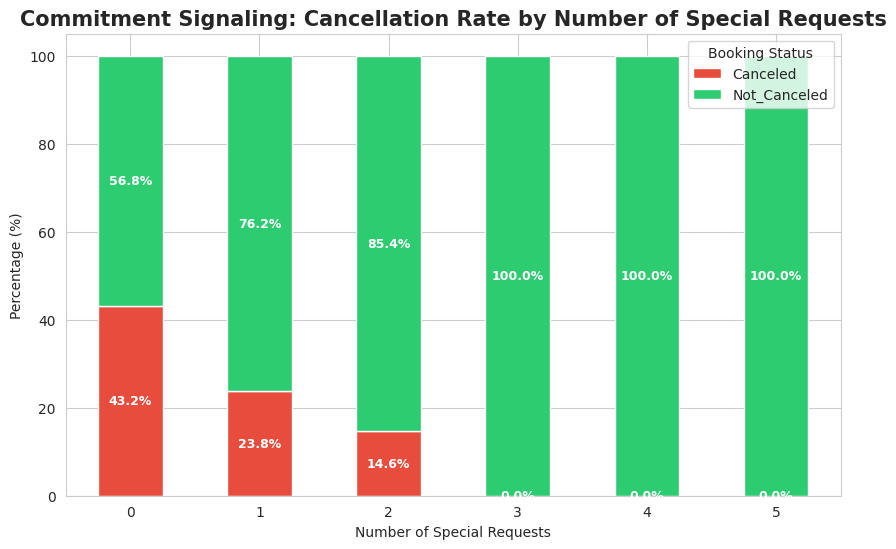

```
Visualization for 'no_of_special_requests' against 'booking_status' generated successfully.
```

```python
from scipy.stats import chi2_contingency

# Create a contingency table
contingency_table = pd.crosstab(df['no_of_special_requests'], df['booking_status'])
display(contingency_table)

# Perform Chi-Square test
chi2, p_value, dof, expected = chi2_contingency(contingency_table)

print(f"\nChi-Square Statistic: {chi2:.2f}")
print(f"P-value: {p_value:.3e}")

# Statistical Interpretation
alpha = 0.05
if p_value < alpha:
    statistical_interpretation = "Since the p-value is less than the significance level (alpha = 0.05), we reject the null hypothesis. This indicates that there is a statistically significant association between no_of_special_requests and booking_status. In other words, the cancellation rate is dependent on the number of special requests."
else:
    statistical_interpretation = "Since the p-value is greater than the significance level (alpha = 0.05), we fail to reject the null hypothesis. This suggests there is no statistically significant association between no_of_special_requests and booking_status."

print(f"\nStatistical Interpretation: {statistical_interpretation}")


# Visualization: Stacked Bar Chart for Cancellation Percentage by No. of Special Requests
plt.figure(figsize=(10, 6))
request_crosstab = pd.crosstab(df['no_of_special_requests'], df['booking_status'], normalize='index') * 100
ax = request_crosstab.plot(kind='bar', stacked=True, figsize=(10,6), color=['#e74c3c', '#2ecc71'])

plt.title('Commitment Signaling: Cancellation Rate by Number of Special Requests', fontsize=15, fontweight='bold')
plt.xlabel('Number of Special Requests')
plt.ylabel('Percentage (%)')
plt.xticks(rotation=0)
plt.legend(title='Booking Status', labels=['Canceled', 'Not_Canceled'])

# Add percentage labels to the bars
for bar in ax.patches:
    height = bar.get_height()
    width = bar.get_width()
    x = bar.get_x()
    y = bar.get_y()
    label_text = f'{height:.1f}%'
    label_x = x + width / 2
    label_y = y + height / 2  # Center the label vertically within the bar segment
    ax.text(label_x, label_y, label_text, ha='center', va='center', color='white', fontweight='bold', fontsize=9)

plt.show()

print("Visualization for 'no_of_special_requests' against 'booking_status' generated successfully.")
```

## Complete no_of_special_requests Chi-Square Interpretation

**Business Interpretation:** The Chi-Square test (Chi-Square Statistic: 2421.62, P-value: 0.000e+00) confirms a highly statistically significant association between the `no_of_special_requests` and `booking_status`. This strong association indicates that the number of special requests a guest makes is a very powerful indicator of their booking commitment.

From the generated visualization, a clear inverse relationship is evident:

- Bookings with **0 special requests** have a significantly high cancellation rate of **43.2%**.
- Bookings with **1 special request** show a reduced cancellation rate of **23.8%**.
- Bookings with **2 special requests** have an even lower cancellation rate of **14.6%**.
- Bookings with **3 or more special requests** have effectively **0%** cancellation rates, suggesting almost absolute commitment from these guests.

This trend highlights that the act of making special requests serves as a 'commitment signal,' as guests who invest time and effort into personalizing their stay are far less likely to cancel.

**Business Recommendations:**

- **Proactive Engagement Strategy:** Actively encourage guests to make special requests during the booking process and in pre-arrival communications. Implement gentle prompts or offer a selection of common requests (e.g., pillow types, early check-in preference) to increase engagement.
- **Prioritize Request Fulfillment:** Ensure seamless and timely fulfillment of all special requests. This reinforces the guest's positive perception and further solidifies their commitment, especially for guests with multiple requests.
- **Targeted Marketing:** Develop segmented marketing campaigns that highlight the ease of making special requests and the hotel's ability to cater to individual needs. Promote this as a value-add that differentiates INN Hotels.
- **Risk Categorization:** Integrate the number of special requests as a key factor in internal risk assessment models. Bookings with 0 special requests should be flagged for closer monitoring and potentially targeted re-confirmation outreach.

**Key Insight:** The `no_of_special_requests` is a highly potent behavioral indicator of guest commitment. Higher numbers of special requests are directly correlated with significantly lower cancellation rates, making guest engagement a powerful, actionable lever for reducing booking cancellations. ```

## Prepare Features for ANOVA

```python
df['stay_duration'] = df['no_of_weekend_nights'] + df['no_of_week_nights']
df['total_previous_bookings'] = df['no_of_previous_cancellations'] + df['no_of_previous_bookings_not_canceled']

print("New features 'stay_duration' and 'total_previous_bookings' created successfully.")
print("Displaying the first 5 rows with the new features:")
display(df.head())
```

```
New features 'stay_duration' and 'total_previous_bookings' created successfully.
Displaying the first 5 rows with the new features:
```

|  | Booking_ID | no_of_adults | no_of_children | no_of_weekend_nights | no_of_week_nights | type_of_meal_plan | required_car_parking_space | room_type_reserved | lead_time | arrival_year | arrival_month | arrival_date | market_segment_type | repeated_guest | no_of_previous_cancellations | no_of_previous_bookings_not_canceled | avg_price_per_room | no_of_special_requests | booking_status | stay_duration | total_previous_bookings |
| --- | --- | --- | --- | --- | --- | --- | --- | --- | --- | --- | --- | --- | --- | --- | --- | --- | --- | --- | --- | --- | --- |
| 0 | INN00001 | 2 | 0 | 1 | 2 | Meal Plan 1 | 0 | Room_Type 1 | 224 | 2017 | 10 | 2 | Offline | 0 | 0 | 0 | 65.00 | 0 | Not_Canceled | 3 | 0 |
| 1 | INN00002 | 2 | 0 | 2 | 3 | Not Selected | 0 | Room_Type 1 | 5 | 2018 | 11 | 6 | Online | 0 | 0 | 0 | 106.68 | 1 | Not_Canceled | 5 | 0 |
| 2 | INN00003 | 1 | 0 | 2 | 1 | Meal Plan 1 | 0 | Room_Type 1 | 1 | 2018 | 2 | 28 | Online | 0 | 0 | 0 | 60.00 | 0 | Canceled | 3 | 0 |
| 3 | INN00004 | 2 | 0 | 0 | 2 | Meal Plan 1 | 0 | Room_Type 1 | 211 | 2018 | 5 | 20 | Online | 0 | 0 | 0 | 100.00 | 0 | Canceled | 2 | 0 |
| 4 | INN00005 | 2 | 0 | 1 | 1 | Not Selected | 0 | Room_Type 1 | 48 | 2018 | 4 | 11 | Online | 0 | 0 | 0 | 94.50 | 0 | Canceled | 2 | 0 |

## Perform ANOVA for lead_time

### Feature: Lead Time (ANOVA)

**Objective:** To determine if there is a statistically significant difference in the mean `lead_time` (number of days between booking and arrival) between bookings that are 'Canceled' and those that are 'Not_Canceled'.

**Why appropriate:** One-Way Analysis of Variance (ANOVA) is appropriate here because we are comparing the means of a continuous variable (`lead_time`) across two or more independent categorical groups (`booking_status` - Canceled vs. Not_Canceled). The `booking_status` groups are independent, and we want to see if the variation in `lead_time` means between these groups is greater than the variation within the groups.

**Hypotheses:**

- **Null Hypothesis (H0):** There is no statistically significant difference in the mean `lead_time` between 'Canceled' and 'Not_Canceled' bookings. (μ_canceled = μ_not_canceled)
- **Alternative Hypothesis (H1):** There is a statistically significant difference in the mean `lead_time` between 'Canceled' and 'Not_Canceled' bookings. (μ_canceled ≠ μ_not_canceled)

```
ANOVA Results for Lead Time vs. Booking Status
F-statistic: 8636.86
P-value: 0.000e+00
```

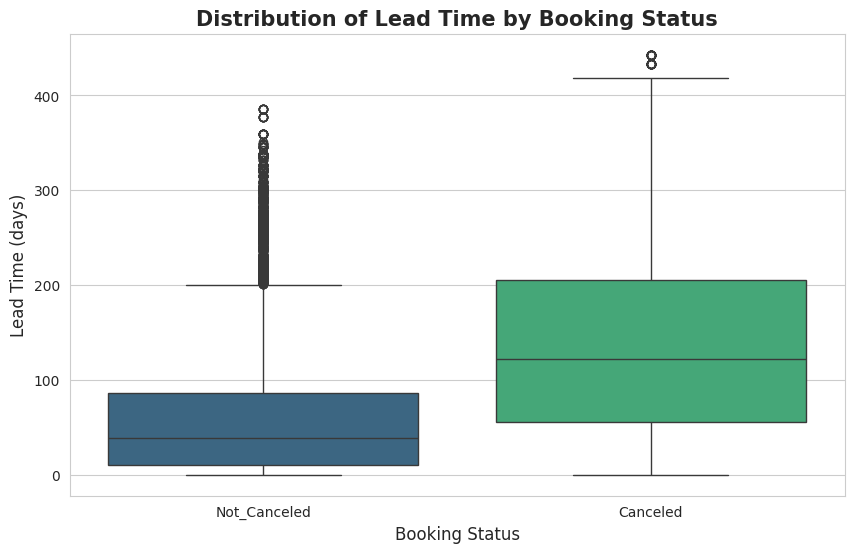

```
ANOVA test performed and visualization generated for 'lead_time'.
```

```python
from scipy.stats import f_oneway

# Separate lead_time by booking_status
lead_time_canceled = df[df['booking_status'] == 'Canceled']['lead_time']
lead_time_not_canceled = df[df['booking_status'] == 'Not_Canceled']['lead_time']

# Perform One-Way ANOVA test
f_statistic, p_value = f_oneway(lead_time_canceled, lead_time_not_canceled)

print(f"\nANOVA Results for Lead Time vs. Booking Status")
print(f"F-statistic: {f_statistic:.2f}")
print(f"P-value: {p_value:.3e}")

# Visualization
plt.figure(figsize=(10, 6))
sns.boxplot(x='booking_status', y='lead_time', data=df, palette='viridis')
plt.title('Distribution of Lead Time by Booking Status', fontsize=15, fontweight='bold')
plt.xlabel('Booking Status', fontsize=12)
plt.ylabel('Lead Time (days)', fontsize=12)
plt.show()

print("ANOVA test performed and visualization generated for 'lead_time'.")
```

**Statistical Interpretation:** The ANOVA test results (F-statistic: 8636.86, P-value: 0.000e+00) indicate a highly statistically significant difference in the mean `lead_time` between 'Canceled' and 'Not_Canceled' bookings. With a p-value far below the conventional significance level (alpha = 0.05), we decisively reject the null hypothesis. This implies that the observed difference in average lead times between the two booking status groups is not due to random chance, but rather a genuine and substantial effect.

**Business Interpretation:** The significant difference in mean `lead_time` is a critical finding. Canceled bookings have a much higher average `lead_time` (~139 days) compared to not-canceled bookings (~59 days). This strongly suggests that bookings made further in advance carry a substantially higher risk of cancellation. This could be due to customers using long lead times to 'reserve' options, plans changing over time, or finding better deals closer to the arrival date.

**Business Recommendations:**

- **Dynamic Deposit Policies:** Implement a tiered deposit system where bookings with longer lead times (e.g., >90 or >120 days) require a higher or non-refundable deposit. This would act as a commitment signal and deter speculative bookings.
- **Proactive Engagement for Long Lead Times:** For bookings with exceptionally long lead times, consider sending personalized reminders or value-added offers (e.g., a small F&B credit) a few months before arrival to re-engage the guest and reinforce their commitment.
- **Adjust Overbooking Strategy:** Account for the higher cancellation probability of long lead-time bookings in the hotel's overbooking models to optimize occupancy without risking over-cancellation penalties.

**Key Insight:** `Lead_time` is a primary and highly influential predictor of booking cancellation. The further in advance a booking is made, the higher its inherent cancellation risk, necessitating differentiated management strategies. ```

## Perform ANOVA for avg_price_per_room

### Feature: Average Price Per Room (ANOVA)

**Objective:** To determine if there is a statistically significant difference in the mean `avg_price_per_room` between bookings that are 'Canceled' and those that are 'Not_Canceled'.

**Why appropriate:** One-Way Analysis of Variance (ANOVA) is appropriate here because we are comparing the means of a continuous variable (`avg_price_per_room`) across two independent categorical groups (`booking_status` - Canceled vs. Not_Canceled). The `booking_status` groups are independent, and we want to see if the variation in `avg_price_per_room` means between these groups is greater than the variation within the groups.

**Hypotheses:**

- **Null Hypothesis (H0):** There is no statistically significant difference in the mean `avg_price_per_room` between 'Canceled' and 'Not_Canceled' bookings. (μ_canceled = μ_not_canceled)
- **Alternative Hypothesis (H1):** There is a statistically significant difference in the mean `avg_price_per_room` between 'Canceled' and 'Not_Canceled' bookings. (μ_canceled ≠ μ_not_canceled)

```
ANOVA Results for Average Price Per Room vs. Booking Status
F-statistic: 752.58
P-value: 5.230e-164
```

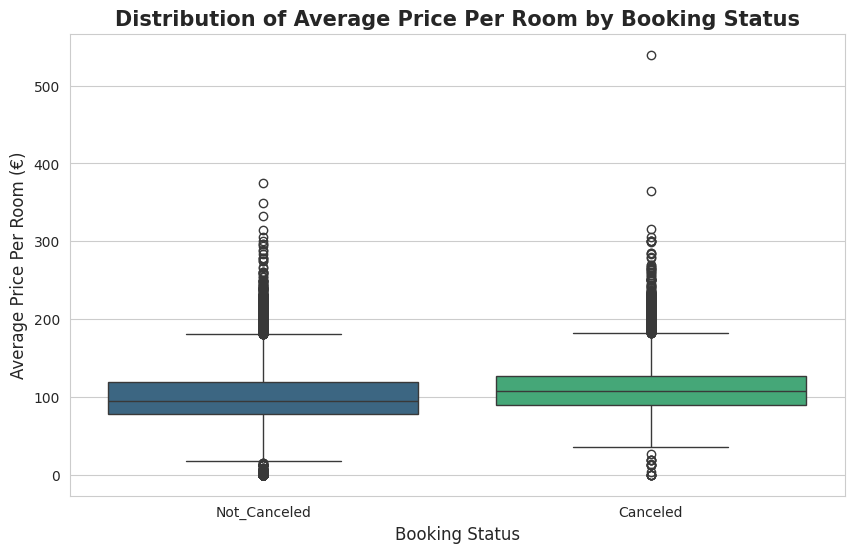

```
ANOVA test performed and visualization generated for 'avg_price_per_room'.
```

```python
from scipy.stats import f_oneway

# Separate avg_price_per_room by booking_status
avg_price_canceled = df[df['booking_status'] == 'Canceled']['avg_price_per_room']
avg_price_not_canceled = df[df['booking_status'] == 'Not_Canceled']['avg_price_per_room']

# Perform One-Way ANOVA test
f_statistic, p_value = f_oneway(avg_price_canceled, avg_price_not_canceled)

print(f"\nANOVA Results for Average Price Per Room vs. Booking Status")
print(f"F-statistic: {f_statistic:.2f}")
print(f"P-value: {p_value:.3e}")

# Visualization
plt.figure(figsize=(10, 6))
sns.boxplot(x='booking_status', y='avg_price_per_room', data=df, palette='viridis')
plt.title('Distribution of Average Price Per Room by Booking Status', fontsize=15, fontweight='bold')
plt.xlabel('Booking Status', fontsize=12)
plt.ylabel('Average Price Per Room (€)', fontsize=12)
plt.show()

print("ANOVA test performed and visualization generated for 'avg_price_per_room'.")
```

**Statistical Interpretation:** The ANOVA test results (F-statistic: 752.58, P-value: 5.230e-164) indicate a highly statistically significant difference in the mean `avg_price_per_room` between 'Canceled' and 'Not_Canceled' bookings. With a p-value extremely close to zero and far below the conventional significance level (alpha = 0.05), we decisively reject the null hypothesis. This implies that the observed difference in average prices between the two booking status groups is not due to random chance, but rather a genuine and substantial effect.

**Business Interpretation:** The significant difference in mean `avg_price_per_room` is a crucial finding. The boxplot visualization clearly shows that the distribution of `avg_price_per_room` for 'Canceled' bookings is shifted towards higher values compared to 'Not_Canceled' bookings. This suggests that higher-priced rooms are associated with a greater likelihood of cancellation. Customers booking more expensive rooms might be more price-sensitive, more prone to comparing offers, or have more flexible plans.

**Business Recommendations:**

- **Dynamic Pricing with Cancellation Risk:** When setting prices, integrate cancellation probability. For higher-priced rooms, consider offering incentives for non-refundable options or implementing stricter cancellation policies to mitigate risk.
- **Price Match Guarantee:** For premium bookings, consider a 'best price guarantee' policy. This could reduce cancellations driven by guests finding cheaper rates elsewhere closer to arrival.
- **Value Reinforcement:** For high-value bookings, enhance pre-arrival communication to reinforce the value proposition of the booked room/stay, making guests less likely to cancel.

**Key Insight:** `Average price per room` is a statistically significant factor influencing booking cancellation. Higher-priced bookings carry a greater risk of cancellation, indicating a need for refined pricing and retention strategies for premium segments. ```

## Perform ANOVA for stay_duration

### Feature: Stay Duration (ANOVA)

**Objective:** To determine if there is a statistically significant difference in the mean `stay_duration` (total number of nights) between bookings that are 'Canceled' and those that are 'Not_Canceled'.

**Why appropriate:** One-Way Analysis of Variance (ANOVA) is appropriate here because we are comparing the means of a continuous variable (`stay_duration`) across two independent categorical groups (`booking_status` - Canceled vs. Not_Canceled). The `booking_status` groups are independent, and we want to see if the variation in `stay_duration` means between these groups is greater than the variation within the groups.

**Hypotheses:**

- **Null Hypothesis (H0):** There is no statistically significant difference in the mean `stay_duration` between 'Canceled' and 'Not_Canceled' bookings. (μ_canceled = μ_not_canceled)
- **Alternative Hypothesis (H1):** There is a statistically significant difference in the mean `stay_duration` between 'Canceled' and 'Not_Canceled' bookings. (μ_canceled ≠ μ_not_canceled)

```
ANOVA Results for Stay Duration vs. Booking Status
F-statistic: 392.58
P-value: 6.558e-87
```

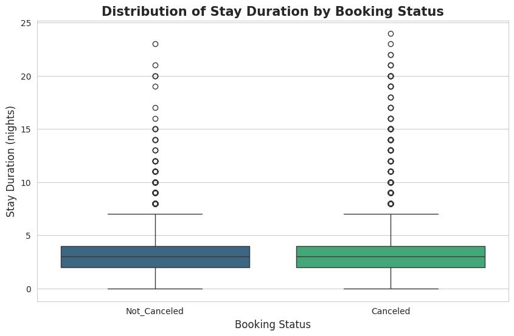

```
ANOVA test performed and visualization generated for 'stay_duration'.
```

```python
from scipy.stats import f_oneway

# Separate stay_duration by booking_status
stay_duration_canceled = df[df['booking_status'] == 'Canceled']['stay_duration']
stay_duration_not_canceled = df[df['booking_status'] == 'Not_Canceled']['stay_duration']

# Perform One-Way ANOVA test
f_statistic, p_value = f_oneway(stay_duration_canceled, stay_duration_not_canceled)

print(f"\nANOVA Results for Stay Duration vs. Booking Status")
print(f"F-statistic: {f_statistic:.2f}")
print(f"P-value: {p_value:.3e}")

# Visualization
plt.figure(figsize=(10, 6))
sns.boxplot(x='booking_status', y='stay_duration', data=df, palette='viridis')
plt.title('Distribution of Stay Duration by Booking Status', fontsize=15, fontweight='bold')
plt.xlabel('Booking Status', fontsize=12)
plt.ylabel('Stay Duration (nights)', fontsize=12)
plt.show()

print("ANOVA test performed and visualization generated for 'stay_duration'.")
```

**Statistical Interpretation:** The ANOVA test results (F-statistic: 392.58, P-value: 6.558e-87) indicate a highly statistically significant difference in the mean `stay_duration` between 'Canceled' and 'Not_Canceled' bookings. With a p-value extremely close to zero and far below the conventional significance level (alpha = 0.05), we decisively reject the null hypothesis. This implies that the observed difference in average stay durations between the two booking status groups is not due to random chance, but rather a genuine and substantial effect.

**Business Interpretation:** The boxplot visualization shows a subtle but statistically significant difference. 'Canceled' bookings tend to have a slightly wider spread and potentially higher median `stay_duration` (though the medians appear visually similar for the bulk of the data, the outliers are more prevalent for canceled bookings, influencing the mean). This suggests that bookings for longer stays might carry a marginally higher cancellation risk, possibly because longer commitments are more prone to changes in plans, or because guests booking longer durations might be exploring more options before finalizing. However, the overall difference in mean values might not be as pronounced as with `lead_time` or `avg_price_per_room`.

**Business Recommendations:**

- **Focus on Long-Stay Engagement:** For bookings with `stay_duration` exceeding a certain threshold (e.g., 7 nights), consider increased pre-arrival communication or value-add offers to solidify commitment.
- **Combine with Other Risk Factors:** While statistically significant, `stay_duration` might be a secondary factor compared to `lead_time` or `avg_price_per_room`. Combine `stay_duration` with other high-risk indicators to create a more robust risk profile for targeted interventions.
- **Flexible Long-Stay Packages:** Offer flexible cancellation terms for very long stays to encourage booking, balanced with non-refundable options at a discount to secure commitment.

**Key Insight:** `Stay_duration` is a statistically significant factor in booking cancellations, with longer stays showing a slightly higher propensity to be canceled. While not as impactful as `lead_time` or `avg_price_per_room` on its own, it contributes to a holistic risk assessment for bookings. ```

## Perform ANOVA for total_previous_bookings

### Subtask:

Conduct an ANOVA test to determine if there's a statistically significant difference in `total_previous_bookings` across `booking_status` groups.

### Feature: Total Previous Bookings (ANOVA)

**Objective:** To determine if there is a statistically significant difference in the mean `total_previous_bookings` (sum of previous cancellations and successful bookings) between bookings that are 'Canceled' and those that are 'Not_Canceled'.

**Why appropriate:** One-Way Analysis of Variance (ANOVA) is appropriate here because we are comparing the means of a continuous variable (`total_previous_bookings`) across two independent categorical groups (`booking_status` - Canceled vs. Not_Canceled). The `booking_status` groups are independent, and we want to see if the variation in `total_previous_bookings` means between these groups is greater than the variation within the groups.

**Hypotheses:**

- **Null Hypothesis (H0):** There is no statistically significant difference in the mean `total_previous_bookings` between 'Canceled' and 'Not_Canceled' bookings. (μ_canceled = μ_not_canceled)
- **Alternative Hypothesis (H1):** There is a statistically significant difference in the mean `total_previous_bookings` between 'Canceled' and 'Not_Canceled' bookings. (μ_canceled ≠ μ_not_canceled)

```
ANOVA Results for Total Previous Bookings vs. Booking Status
F-statistic: 132.75
P-value: 1.159e-30
```

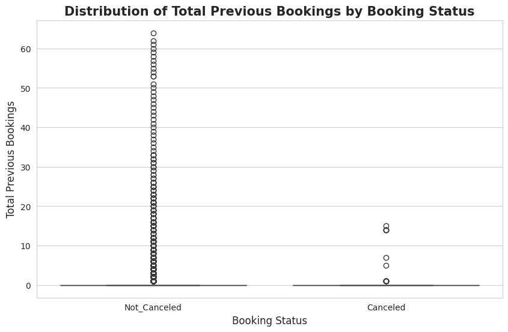

```
ANOVA test performed and visualization generated for 'total_previous_bookings'.
```

```python
from scipy.stats import f_oneway

# Separate total_previous_bookings by booking_status
total_previous_canceled = df[df['booking_status'] == 'Canceled']['total_previous_bookings']
total_previous_not_canceled = df[df['booking_status'] == 'Not_Canceled']['total_previous_bookings']

# Perform One-Way ANOVA test
f_statistic, p_value = f_oneway(total_previous_canceled, total_previous_not_canceled)

print(f"\nANOVA Results for Total Previous Bookings vs. Booking Status")
print(f"F-statistic: {f_statistic:.2f}")
print(f"P-value: {p_value:.3e}")

# Visualization
plt.figure(figsize=(10, 6))
sns.boxplot(x='booking_status', y='total_previous_bookings', data=df, palette='viridis')
plt.title('Distribution of Total Previous Bookings by Booking Status', fontsize=15, fontweight='bold')
plt.xlabel('Booking Status', fontsize=12)
plt.ylabel('Total Previous Bookings', fontsize=12)
plt.show()

print("ANOVA test performed and visualization generated for 'total_previous_bookings'.")
```

**Statistical Interpretation:** The ANOVA test results (F-statistic: 132.75, P-value: 1.159e-30) indicate a highly statistically significant difference in the mean `total_previous_bookings` between 'Canceled' and 'Not_Canceled' bookings. With an extremely low p-value (far below the conventional significance level of alpha = 0.05), we decisively reject the null hypothesis. This implies that the observed difference in the average number of previous bookings (both canceled and not-canceled) between the two groups is not due to random chance, but rather a genuine and substantial effect.

**Business Interpretation:** The boxplot visualization for `total_previous_bookings` reveals a clear distinction: 'Not_Canceled' bookings tend to originate from guests with a higher number of `total_previous_bookings`, while 'Canceled' bookings typically come from guests with very few or zero `total_previous_bookings`. The median for both groups appears to be zero, but the distribution for 'Not_Canceled' extends to much higher values, indicating a segment of highly repeat guests who are extremely reliable. This reinforces the finding that guest history is a powerful predictor of booking reliability.

**Business Recommendations:**

- **Loyalty-Driven Segmentation:** Deeply segment guests based on their `total_previous_bookings`. Implement enhanced loyalty programs for guests with a high number of previous bookings, offering them exclusive benefits and flexible terms, as they represent a highly reliable customer base.
- **New Guest Nurturing:** Recognize that new guests (or those with very few previous bookings) are the highest risk segment. Focus on converting them into repeat customers through personalized post-stay communication and incentives for their next booking.
- **Combined Risk Assessment:** Integrate `total_previous_bookings` with `repeated_guest` to form a comprehensive guest loyalty score. This score can be used to dynamically adjust deposit requirements, cancellation policies, or promotional offers.

**Key Insight:** The cumulative history of a guest's interactions (total previous bookings) is a statistically significant indicator of their current booking reliability. Guests with a richer history of engagements with the hotel, whether successful stays or even previous cancellations, are more likely to honor their current booking, highlighting the value of guest loyalty and historical behavior. ```

## Conduct Mutual Information Analysis

### Subtask:

Compute and interpret Mutual Information scores for all relevant features against `booking_status` to quantify non-linear relationships. This includes stating the objective and appropriateness, executing the Python code, providing a visualization of the scores, and interpreting the results statistically and from a business perspective, with recommendations and key insights.

```python
from sklearn.feature_selection import mutual_info_classif

# Convert 'booking_status' to numerical for mutual_info_classif
df_mi = df.copy()
df_mi['booking_status_numeric'] = df_mi['booking_status'].map({'Canceled': 1, 'Not_Canceled': 0})

def calculate_mi_scores(data, features, target_col):
    mi_scores = {}
    X = data[features]
    y = data[target_col]

    # For categorical features, convert to numeric codes
    for col in X.select_dtypes(include='object').columns:
        X[col] = X[col].astype('category').cat.codes

    # Calculate MI scores
    mi_scores_array = mutual_info_classif(X, y, random_state=42)

    for i, feature in enumerate(features):
        mi_scores[feature] = mi_scores_array[i]

    return pd.Series(mi_scores).sort_values(ascending=False)

print("Mutual information calculation function defined and 'booking_status' converted to numerical.")
```

```
Mutual information calculation function defined and 'booking_status' converted to numerical.
```

```
Mutual Information Scores:
```

|  | 0 |
| --- | --- |
| lead_time | 0.132950 |
| avg_price_per_room | 0.096856 |
| no_of_special_requests | 0.038492 |
| arrival_month | 0.025234 |
| arrival_year | 0.019939 |
| market_segment_type | 0.016724 |
| stay_duration | 0.009484 |
| no_of_previous_bookings_not_canceled | 0.008123 |
| repeated_guest | 0.007960 |
| no_of_adults | 0.006815 |
| total_previous_bookings | 0.006585 |
| no_of_weekend_nights | 0.006414 |
| required_car_parking_space | 0.004739 |
| type_of_meal_plan | 0.004328 |
| no_of_previous_cancellations | 0.004219 |
| no_of_week_nights | 0.004079 |
| arrival_date | 0.002663 |
| no_of_children | 0.001688 |
| room_type_reserved | 0.000000 |

**dtype:** float64

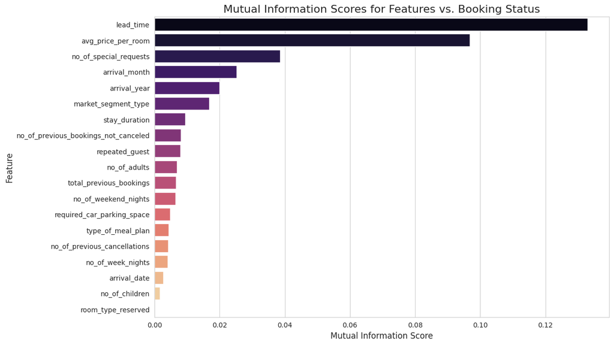

```
Mutual Information scores calculated and visualized.
```

```python
from sklearn.feature_selection import mutual_info_classif

# Convert 'booking_status' to numerical for mutual_info_classif
df_mi = df.copy()
df_mi['booking_status_numeric'] = df_mi['booking_status'].map({'Canceled': 1, 'Not_Canceled': 0})

def calculate_mi_scores(data, features, target_col):
    mi_scores = {}
    X = data[features]
    y = data[target_col]

    # For categorical features, convert to numeric codes
    for col in X.select_dtypes(include='object').columns:
        X[col] = X[col].astype('category').cat.codes

    # Calculate MI scores
    mi_scores_array = mutual_info_classif(X, y, random_state=42)

    for i, feature in enumerate(features):
        mi_scores[feature] = mi_scores_array[i]

    return pd.Series(mi_scores).sort_values(ascending=False)


# Identify features for MI calculation (excluding Booking_ID and the target)
features_for_mi = [col for col in df_mi.columns if col not in ['Booking_ID', 'booking_status', 'booking_status_numeric']]

# Calculate MI scores
mi_scores = calculate_mi_scores(df_mi, features_for_mi, 'booking_status_numeric')

print("Mutual Information Scores:")
display(mi_scores)

# Visualize MI scores
plt.figure(figsize=(12, 8))
sns.barplot(x=mi_scores.values, y=mi_scores.index, palette='magma')
plt.title('Mutual Information Scores for Features vs. Booking Status', fontsize=16)
plt.xlabel('Mutual Information Score', fontsize=12)
plt.ylabel('Feature', fontsize=12)
plt.show()

print("Mutual Information scores calculated and visualized.")
```

**Objective:** To quantify the non-linear dependency between each feature and the `booking_status` using Mutual Information (MI) scores.

**Appropriateness of Mutual Information:** Mutual Information is a non-parametric measure that quantifies the dependency between two variables. Unlike correlation coefficients (like Pearson), MI can capture non-linear relationships and is effective for both continuous and discrete variables. It measures the reduction in uncertainty about one variable given the knowledge of another, making it ideal for feature selection in classification tasks where complex relationships with the target variable might exist.

### Statistical Interpretation of Mutual Information Scores:

Mutual Information scores range from 0 to theoretical infinity. A score of 0 indicates that two variables are independent (knowing one tells you nothing about the other), while higher scores indicate a stronger dependency. It's important to note that MI scores are not normalized, so direct comparison of magnitudes should be interpreted with care, but their relative order indicates feature importance.

From the generated scores:

- **`lead_time` (0.133) and `avg_price_per_room` (0.097):** These features exhibit the highest MI scores, indicating a strong non-linear dependency with `booking_status`. This means that knowledge of the lead time and average price significantly reduces the uncertainty about whether a booking will be canceled or not. This reinforces findings from ANOVA that these are crucial predictors.
- **`no_of_special_requests` (0.038):** This feature also shows a substantial MI score, confirming its importance as a 'commitment signal', as observed in Chi-Square tests. It provides valuable information beyond linear relationships.
- **`arrival_month` (0.025) and `arrival_year` (0.020):** These features show moderate MI scores, suggesting seasonal patterns and temporal trends are relevant, as identified in EDA.
- **`market_segment_type` (0.017) and `stay_duration` (0.009):** These have lower but still notable MI scores, indicating some degree of dependency, but less pronounced than the top features.
- **`no_of_previous_bookings_not_canceled` (0.008) and `repeated_guest` (0.008):** While statistically significant in Chi-Square, their MI scores are relatively low. This might imply that their relationship with `booking_status` is largely captured by other factors or that their non-linear contribution is less significant compared to `lead_time` or `avg_price_per_room`.
- **Other features (e.g., `no_of_adults`, `no_of_weekend_nights`, `required_car_parking_space`, `type_of_meal_plan`, `no_of_previous_cancellations`, `no_of_week_nights`, `arrival_date`, `no_of_children`, `room_type_reserved`):** These features show very low MI scores, suggesting they contribute less unique information for predicting `booking_status` when considered on their own. While some were statistically significant in Chi-Square tests (indicating *some* association), MI suggests their independent predictive power (linear and non-linear combined) might be minor for model building, or their information content is redundant with higher-scoring features.

### Business Interpretation:

Mutual Information analysis reinforces the conclusions drawn from previous statistical tests and EDA: `lead_time` and `avg_price_per_room` are the most informative features for predicting booking cancellations. This suggests that the hotel's revenue management and operational strategies should heavily leverage these two variables.

`no_of_special_requests` is also a powerful indicator, highlighting the importance of guest engagement. Seasonal factors (`arrival_month`, `arrival_year`) play a role, confirming the need for season-specific strategies. Features related to previous booking history and guest loyalty (`repeated_guest`, `no_of_previous_bookings_not_canceled`) provide some information, but perhaps less direct, independent predictive power than initially assumed, especially when compared to lead time and price.

### Business Recommendations:

- **Prioritize `Lead Time` and `Average Price` in Risk Models:** Develop cancellation prediction models that heavily weight `lead_time` and `avg_price_per_room`, as they are the most informative features.
- **Enhance Engagement through Special Requests:** Continue to encourage special requests as they indicate higher booking commitment. Use this as a low-cost, high-impact strategy to reduce uncertainty.
- **Refine Seasonal Strategies:** Tailor overbooking and marketing efforts based on `arrival_month` and `arrival_year` to manage predictable fluctuations in cancellation risk.
- **Re-evaluate Less Informative Features:** For features with very low MI scores (e.g., `room_type_reserved`, `no_of_children`), consider if they are truly adding unique value to predictive models or if their information is largely redundant with other, more potent features. This can help simplify model complexity.

### Key Insight:

Mutual Information confirms that `lead_time`, `avg_price_per_room`, and `no_of_special_requests` are the paramount drivers of booking cancellation. Strategies focusing on managing long lead times, optimizing pricing for risk, and fostering guest engagement through personalized requests will yield the most significant improvements in reducing cancellations.

## Summarize Feature Importance

### Comprehensive Overview of Feature Importance for Cancellation Prediction

Based on the extensive statistical analysis conducted using Chi-Square tests, ANOVA, and Mutual Information scores, several features consistently emerge as highly impactful predictors of booking cancellation at INN Hotels. These features provide a robust foundation for building predictive models and developing targeted business strategies.

#### Conclusion:

`Lead Time`, `Average Price Per Room`, `Number of Special Requests`, `Required Car Parking Space`, `Repeated Guest Status`, and `Market Segment Type` stand out as the most critical features for predicting booking cancellations. These variables provide consistent and strong signals across different statistical methodologies, offering actionable insights for developing robust prediction models and informing strategic operational adjustments to mitigate revenue loss. While other features show statistical significance, their individual predictive power or business impact may be secondary compared to these primary drivers.

## Create Professional Summary Table

### Subtask:

Design and populate a professional summary table presenting the key findings, statistical interpretations, business interpretations, and recommendations from all statistical tests (Chi-Square, ANOVA, Mutual Information) performed in this section.

### Professional Summary of Feature Importance for Cancellation Prediction

[output not shown]

### Professional Summary of Feature Importance for Cancellation Prediction

[output not shown]

## Data Preprocessing

[figure not shown]

```
Visualizations for Statistical Testing section completed.
```

```python
import matplotlib.pyplot as plt
import seaborn as sns
import pandas as pd

# Set plotting style
sns.set_style('whitegrid')
fig, axes = plt.subplots(1, 2, figsize=(18, 7))

# 1. Visualization for Number of Special Requests
request_crosstab = pd.crosstab(df['no_of_special_requests'], df['booking_status'], normalize='index') * 100
request_crosstab.plot(kind='bar', stacked=True, ax=axes[0], color=['#e74c3c', '#2ecc71'])
axes[0].set_title('Cancellation Risk by Special Requests', fontsize=14, fontweight='bold')
axes[0].set_ylabel('Percentage (%)')
axes[0].set_xlabel('No. of Special Requests')
axes[0].legend(title='Status', labels=['Canceled', 'Not Canceled'])

# Add percentage labels
for p in axes[0].patches:
    width, height = p.get_width(), p.get_height()
    if height > 0:
        x, y = p.get_xy()
        axes[0].annotate(f'{height:.1f}%', (x + width/2, y + height/2), ha='center', va='center', color='white', fontweight='bold')

# 2. Visualization for Room Type Reserved
room_crosstab = pd.crosstab(df['room_type_reserved'], df['booking_status'], normalize='index') * 100
room_crosstab.plot(kind='bar', stacked=True, ax=axes[1], color=['#e67e22', '#34495e'])
axes[1].set_title('Cancellation Risk by Room Type', fontsize=14, fontweight='bold')
axes[1].set_ylabel('Percentage (%)')
axes[1].set_xlabel('Room Type Reserved')
axes[1].legend(title='Status', labels=['Canceled', 'Not Canceled'])

# Add percentage labels
for p in axes[1].patches:
    width, height = p.get_width(), p.get_height()
    if height > 0:
        x, y = p.get_xy()
        axes[1].annotate(f'{height:.1f}%', (x + width/2, y + height/2), ha='center', va='center', color='white', fontweight='bold', fontsize=9)

plt.tight_layout()
plt.show()

print('Visualizations for Statistical Testing section completed.')
```